# Lab 2 Probability, Distributions, and Statistical Questions

Igor Banin, Anthony Joo

## Problem 1

Average cosmic ray background: 5

Average gamma rays emitted by source: 8

A) Show how the probability distribution of the background changes as you integrate (sum) for more days.

```python
%matplotlib inline
import numpy as np
import matplotlib
import pandas as pd
import matplotlib.pyplot as plt
from matplotlib.pyplot import figure
import scipy
from scipy import stats
from scipy.stats import chi2_contingency
```

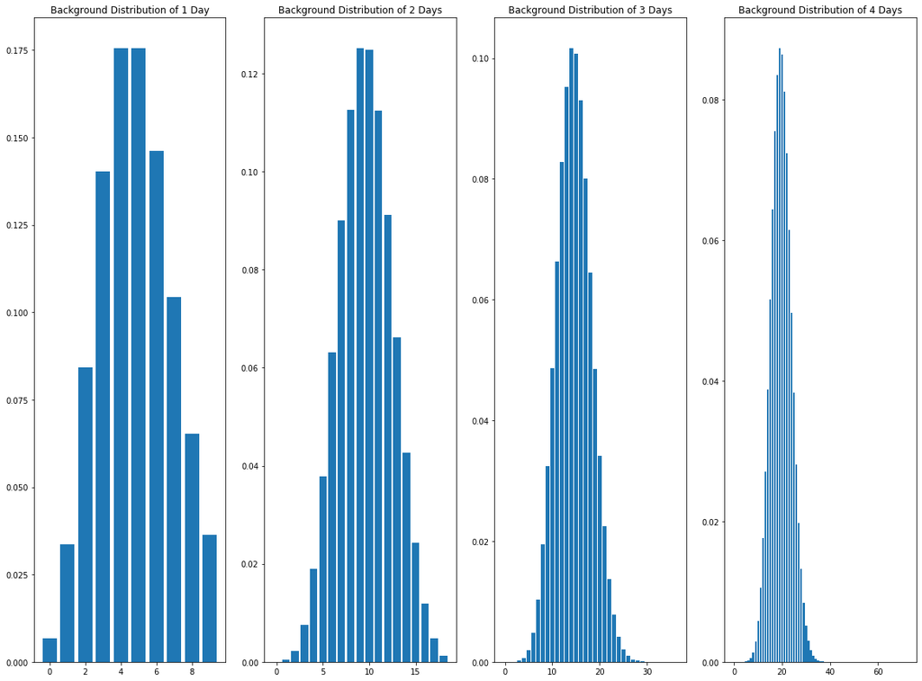

```python
plt.rcParams["figure.figsize"] = (20,15)
fig, ax = plt.subplots(1, 4)
mu = 5 #average cosmic ray background
x = np.arange(0,10)
ax[0].set_title("Background Distribution of 1 Day")
ax[0].bar(x, stats.poisson.pmf(x, mu))

a = np.convolve(stats.poisson.pmf(x, mu), stats.poisson.pmf(x, mu))
x = np.arange(0, len(a))
ax[1].set_title("Background Distribution of 2 Days")
ax[1].bar(x, a)
for i in range(2,4):
    a = np.convolve(a, stats.poisson.pmf(x, mu))
    x = np.arange(0, len(a))
    ax[i].set_title("Background Distribution of " + str(i + 1) + " Days")
    ax[i].bar(x, a)
b = a
```

B) Show that after 5 days, the summed probability distribution is still a Poisson distribution. Explain why this makes sense from a mathematical and conceptual point of view.

[output not shown]

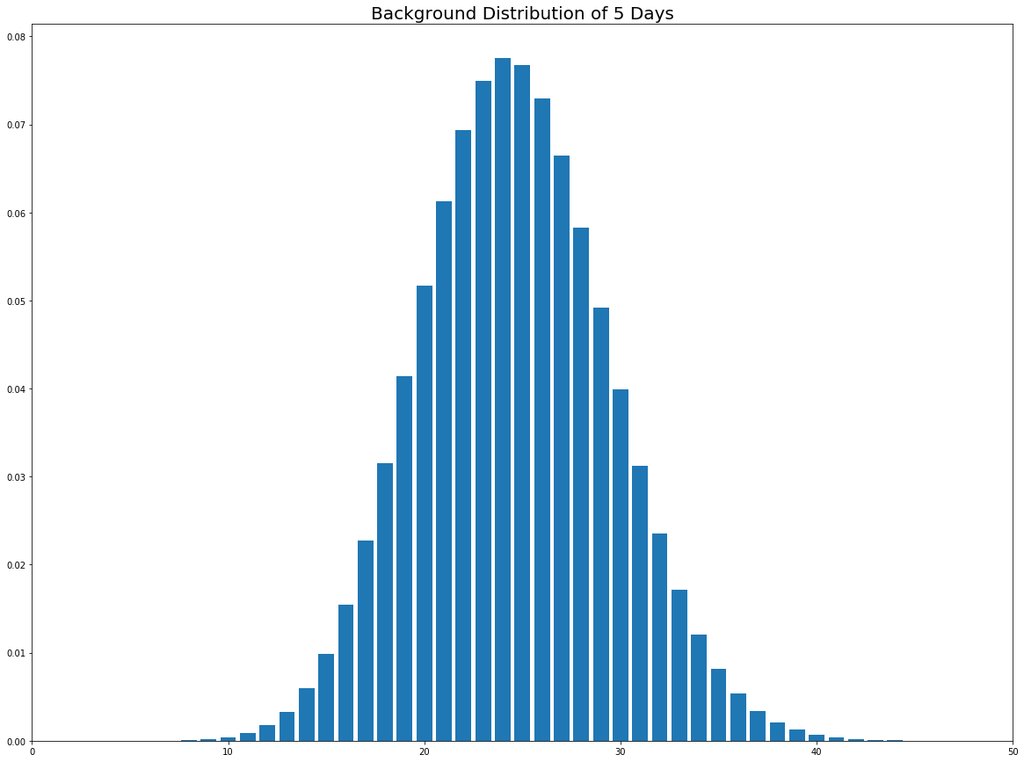

```python
fig, ax = plt.subplots(1, 1)
d = np.convolve(b, stats.poisson.pmf(x, mu))
x = np.arange(0, len(d))
ax.set_title("Background Distribution of 5 Days", fontsize='20')
plt.xlim(0, 50)
ax.bar(x, d)

table = pd.crosstab(d, stats.poisson.pmf(x, mu))
chi2, p, dof, expected = chi2_contingency(table.values)
print("Chi-square value: ", chi2, " P-value: ", p)
```

C) Show how the probability distribution evolves as you average days. Calculate for many different ranges of days, and explore the shape of the distribution as the number of days becomes larger. Discuss this in relation to both B) and the central limit theoem.

Averaging the days keeps the range of the x-axis in the same ball park as we keep convolving the poisson distribution. As the days get larger the peak of the probability distribution steadily decreases, the bars get closer and the distribution continues to get closer and closer to a gaussian distribution. In relation to B, the general shape of the distribution stays the same, because the sum of a poisson is still a poisson distribution. This is inline with the central limit theorem because regardless of the shape of the original distribution, as the sample size increases - the distribution should start to look more and more gaussian.

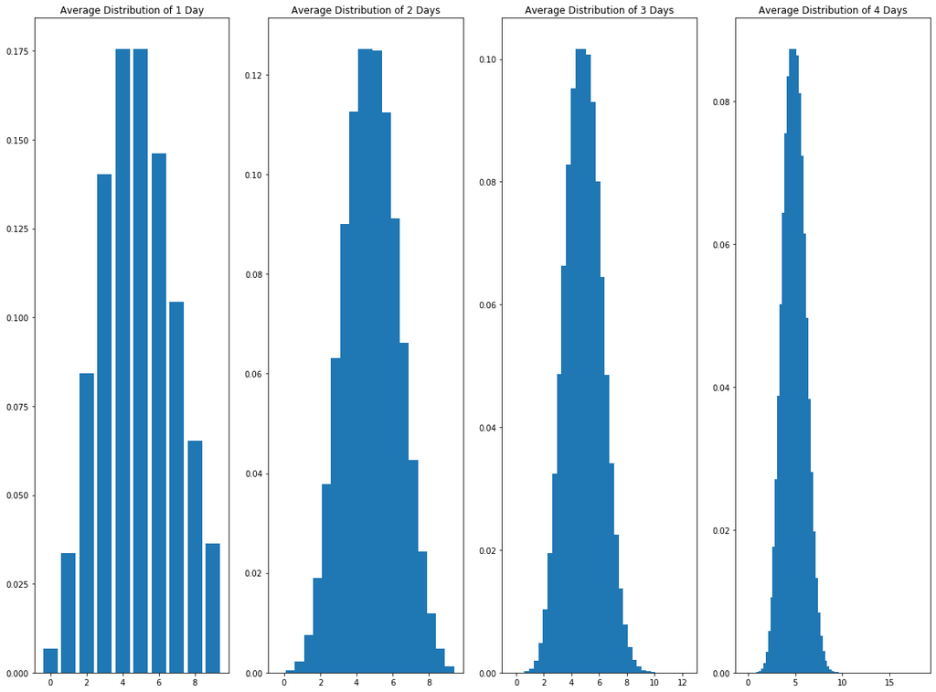

```python
plt.rcParams["figure.figsize"] = (20,15)
fig, ax = plt.subplots(1, 4)
mu = 5 #average cosmic ray background
x = np.arange(0,10)
ax[0].set_title("Average Distribution of 1 Day")
ax[0].bar(x, stats.poisson.pmf(x, mu))

a = np.convolve(stats.poisson.pmf(x, mu), stats.poisson.pmf(x, mu))
x = np.arange(0, len(a))
ax[1].set_title("Average Distribution of 2 Days")
ax[1].bar(x/2, a)
for i in range(2,4):
    a = np.convolve(a, stats.poisson.pmf(x, mu))
    x = np.arange(0, len(a))
    ax[i].set_title("Average Distribution of " + str(i + 1) + " Days")
    ax[i].bar(x/(i+1), a)
b = a
```

D) Pick some number of days N, and assume you saw Y*N gamma rays from your source. Calculate the 'sigma' of your observation. (In reality the number of gamma-rays seen from a source will also fluctuate, but we're going to ignore that complication for a couple of labs.)

```python
N = 5 #number of days
Y = 8 #average number of gamma rays emmitted by source
gammaRays = N*Y

integral = stats.poisson.cdf(gammaRays,25) #Finds the specific cumulative probablity associated with sigma
print("Probability: " + str(integral))
sigma =  stats.norm.ppf(integral) #Finds the sigma associated to the probablity
print("Associated Sigma: " + str(sigma))
```

```
Probability: 0.9979644007190178
Associated Sigma: 2.8725917394181684
```

## Problem 2

A) Show how the distribution changes as you average over more observing intervals.

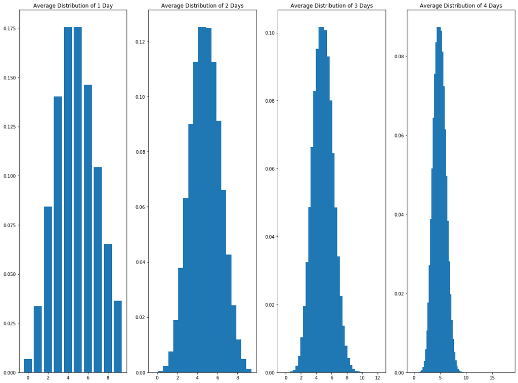

```python
from scipy.stats import rayleigh

plt.rcParams["figure.figsize"] = (20,15)
fig, ax = plt.subplots(1, 4)
mu = 5 #average cosmic ray background
x = np.arange(0,10)
ax[0].set_title("Average Distribution of 1 Day")
ax[0].bar(x, stats.poisson.pmf(x, mu))

a = np.convolve(stats.poisson.pmf(x, mu), stats.poisson.pmf(x, mu))
x = np.arange(0, len(a))
ax[1].set_title("Average Distribution of 2 Days")
ax[1].bar(x/2, a)
for i in range(2,4):
    a = np.convolve(a, stats.poisson.pmf(x, mu))
    x = np.arange(0, len(a))
    ax[i].set_title("Average Distribution of " + str(i + 1) + " Days")
    ax[i].bar(x/(i+1), a)
b = a
```

B) Discuss how the shape changes. Does it approach a Gaussian distribution? If yes, after how many intervals?

## Problem 3

Version 1 You have an alert from LIGO that is also seen in with the X-ray/ultra-violet satellite SWIFT. SWIFT gives you a very precise location, so you take an image of that part of the sky. But because of SWIFT's accuracy, you know which pixel in your image to look for a counterpart in.

A) From looking at all the other pixels in your image, you can measure the width of the background Gaussian distribution X (pick something). Assuming you see a signal of strength Y (pick a floating-point number; optical CCDs are not sensitive enough to count photons so the readings are floating point brightnesses, not integer photons). Calculate the significance of your detection. Can you claim a discovery (traditionally 5-sigma or more)?

I cannot claim a discovery because my sigma is not quite 5 sigma or more.

```python
X = 5
Y = 9.8
probability = stats.norm.cdf(Y, X)
print(probability)
```

```
0.999999206671848
```

```python
sigma =  stats.norm.ppf(probability) #Finds the sigma associated to the probablity
print(sigma)
```

```
4.800000000006716
```

Version 2¶ You have an alert from LIGO, but no associated detection from SWIFT. This could be because it is a black hole-black hole merger, a black hole-neutron star merger (neither seem to emit X-rays or UV light), or it could because SWIFT was indisposed at the time (wrong side of the earth in its orbit). Whatever the cause, you know what region of the sky to look in, but not which pixel.

B) If you have to look for a signal in 10k pixels, what is the probability distribution of your background? (Clearly state the statistical question, then turn that into math using your background distribution from part 1 of this problem.)

In a normal distribution, with a mean of 5, what is the probablity of getting a signal of 9.8 or higher given 10,000 trials.

```python
probabilityV2 = (1 - probability) * 10000
probabsigma = probability * 10000
print("Probability: " + str(probabilityV2))
```

```
Probability: 0.00793328151948991
```

C) Taking your brightest candidate signal from the region (assume it has the same signal as in part 1), calculate the significance of your detection.

```python
sigma2 =  stats.norm.ppf(probabsigma) #Finds the sigma associated to the probablity
print("Sigma " + str(sigma2))
```

```
Sigma nan
```

## Problem 4

The statistical issue we were exploring in the previous problem is called a trials factor (sometimes known as a look-elsewhere effect). This is an important effect, as if you search through a million locations, you would expect to se ~1 one in a million event. However, it is also often over estimated how big an impact this makes on the sensitivity of a search. So in this part of the lab we are going to invert the problem.

Let us again assume we have a Gaussian background (same parameters as Problem 3).

A) Calculate the signal required for a 5-sigma detection in Version 1

```python
signal = X*5
print("A signal strength of " + str(signal) + " is a 5sigma event.")
```

```
A signal strength of 25 is a 5sigma event.
```

B) Calculate the signal required for a 5-sigma detection in Version 2

```python
signal10k = stats.norm.isf(stats.norm.sf(signal, scale=X)/10000, scale=X)
print("Signal strength of " + str(signal10k) + " is required.")
```

```
Signal strength of 32.75268806352667 is required.
```

C) Discuss how much brighter the signal must be for discoverey if you have a trials factor of 10k. Looking at your probability distributions, explain why the sensitivity penalty due to a trials factor is so low.

```python
factor = signal10k/signal
print("Factor of " + str(factor) + " stronger")
```

```
Factor of 1.3101075225410668 stronger
```

D) If you changed the trials factor significantly (orders of magnitude), how large is the effect on your 5-sigma sensitivity threshold?

The 5 sigma sensitivity threshold definitely increases, but not to the rate that I expected.

```python
signal100m = stats.norm.isf(stats.norm.sf(signal, scale=X)/100000000, scale=X)
factor = signal100m/signal10k
print("Signal strength of 100m: " + str(signal100m))
print("Factor of: " + str(factor) + " stronger")
```

```
Signal strength of 100m: 39.04843351809582
Factor of: 1.192220725283922 stronger
```

Extra credit: If you had a different distribution shape (non-Gaussian), how would that affect the sensitivity penalty of many trials? Clearly explain.